# T-Test

Dr. B

Thursday, November 13, 2014

A few different T Tests

```r
##Use my standard openning including call function
if (Sys.info()["sysname"]=="Linux"){
  source('/home/bryan/git/MyWork/StdOpen.R')
}else{
  source('C:/Users/bryan_000/Documents/GitHub/MyWork/StdOpen.R')
}
call("reshape2")
data(ToothGrowth)

##Make dose a factor
ToothGrowth$dose = factor(ToothGrowth$dose, levels=c(0.5,1.0,2.0),labels=c("low","med","high"))

##SPli the datset into testing and training
split <-dfsplit(ToothGrowth)
df.test <-split$testset
df.train <-split$trainset
```

The ToothGrowth dataset explains the relation between the length of teeth in each of 10 guinea pigs at each of three dose levels of Vitamin C (0.5, 1 and 2 mg) with each of two supplement types (orange juice and ascorbic acid).

First, we make a boxplot

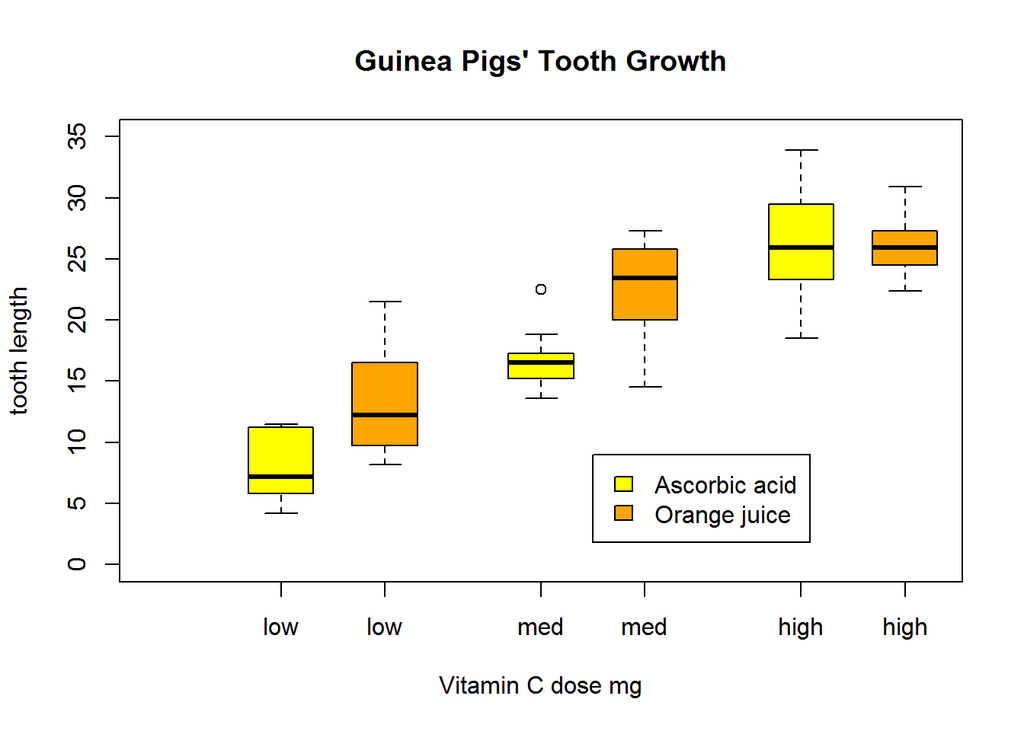

Next, we make a table

```r
table(ToothGrowth$dose,ToothGrowth$supp)
```

```
##
##        OJ VC
##   low  10 10
##   med  10 10
##   high 10 10
```

## Summaries of the Data

Next, we will look at the mean, variance, and standard deviation of tooth length, grouped by supplement type and dose.

```r
###Basic Summary of the Data
summaryBy(len~supp+dose, data=ToothGrowth, FUN=c(mean,var,sd,length))
```

```
##   supp dose len.mean   len.var   len.sd len.length
## 1   OJ  low    13.23 19.889000 4.459709         10
## 2   OJ  med    22.70 15.295556 3.910953         10
## 3   OJ high    26.06  7.049333 2.655058         10
## 4   VC  low     7.98  7.544000 2.746634         10
## 5   VC  med    16.77  6.326778 2.515309         10
## 6   VC high    26.14 23.018222 4.797731         10
```

```r
##Mean
with(ToothGrowth, tapply(len, list(dose,supp), mean))
```

```
##         OJ    VC
## low  13.23  7.98
## med  22.70 16.77
## high 26.06 26.14
```

```r
##Variance
with(ToothGrowth, tapply(len, list(dose,supp), var))
```

```
##             OJ        VC
## low  19.889000  7.544000
## med  15.295556  6.326778
## high  7.049333 23.018222
```

```r
##SD
with(ToothGrowth, tapply(len, list(dose,supp), sd))
```

```
##            OJ       VC
## low  4.459709 2.746634
## med  3.910953 2.515309
## high 2.655058 4.797731
```

```r
##Counts
with(ToothGrowth, tapply(len, list(dose,supp), length))
```

```
##      OJ VC
## low  10 10
## med  10 10
## high 10 10
```

## Hypothesis Tests and Confidence Intervals

#### Paired By Supplement

The hypothesis test was that there was no difference in tooth length between orange juice and ascorbic acid. The alternative hypothesis was that orange juice increased tooth length more than ascorbic acid did.

```r
results <-t.test(ToothGrowth$len[ToothGrowth$supp=="OJ"],ToothGrowth$len[ToothGrowth$supp=="VC"],paired=TRUE, alternative = "greater")
results
```

```
##
##  Paired t-test
##
## data:  ToothGrowth$len[ToothGrowth$supp == "OJ"] and ToothGrowth$len[ToothGrowth$supp == "VC"]
## t = 3.3026, df = 29, p-value = 0.001275
## alternative hypothesis: true difference in means is greater than 0
## 95 percent confidence interval:
##  1.796409      Inf
## sample estimates:
## mean of the differences
##                     3.7
```

#### Paired By Dose (High versus Medium)

The null hypothesis was that there was no difference in tooth length between 2 mg and 1 mg dose levels. The alternative hypothesis was that the 2 mg dose increased tooth length more than 1 mg dose did.

```r
results <-t.test(ToothGrowth$len[ToothGrowth$dose=="high"],ToothGrowth$len[ToothGrowth$dose=="med"],paired=TRUE, alternative = "greater")
results
```

```
##
##  Paired t-test
##
## data:  ToothGrowth$len[ToothGrowth$dose == "high"] and ToothGrowth$len[ToothGrowth$dose == "med"]
## t = 4.6046, df = 19, p-value = 0.00009671
## alternative hypothesis: true difference in means is greater than 0
## 95 percent confidence interval:
##  3.974821      Inf
## sample estimates:
## mean of the differences
##                   6.365
```

#### Paired By Dose (Medium versus Low)

The null hypothesis was that there was no difference in tooth length between the 1 mg and .5 mg dose levels. The alternative hypothesis was that the 1 mg dose increased tooth length more than .5 mg dose did.

```r
results <-t.test(ToothGrowth$len[ToothGrowth$dose=="med"],ToothGrowth$len[ToothGrowth$dose=="low"],paired=TRUE, alternative = "greater")
results
```

```
##
##  Paired t-test
##
## data:  ToothGrowth$len[ToothGrowth$dose == "med"] and ToothGrowth$len[ToothGrowth$dose == "low"]
## t = 6.9669, df = 19, p-value = 0.0000006127
## alternative hypothesis: true difference in means is greater than 0
## 95 percent confidence interval:
##  6.863996      Inf
## sample estimates:
## mean of the differences
##                    9.13
```

## Group Dose by Supplement Type

We extract the data by supplement type, creating two new data frames, so we can run various T-tests.

```r
## Pull out dosage by supplement
vcdf <-subset (ToothGrowth,supp=="VC")
ojdf <-subset (ToothGrowth,supp=="OJ")
```

### Paired High Dose

The null hypothesis was that there was no difference in tooth length between the dose levels by supplement type. The alternative hypothesis was that the at the high dose, orange juice supplement increased tooth length more than ascorbic acid did.

```r
## Check High dosages
results <-t.test(ojdf$len[ojdf$dose=="high"],vcdf$len[vcdf$dose=="high"],paired=TRUE, alternative = "greater")
results
```

```
##
##  Paired t-test
##
## data:  ojdf$len[ojdf$dose == "high"] and vcdf$len[vcdf$dose == "high"]
## t = -0.0426, df = 9, p-value = 0.5165
## alternative hypothesis: true difference in means is greater than 0
## 95 percent confidence interval:
##  -3.523109       Inf
## sample estimates:
## mean of the differences
##                   -0.08
```

### Paired Medium Dose

The null hypothesis was that there was no difference in tooth length between the dose levels by supplement type. The alternative hypothesis was that the at the medium dose, orange juice supplement increased tooth length more than ascorbic acid did.

```r
## Check Medium dosages
results <-t.test(ojdf$len[ojdf$dose=="med"],vcdf$len[vcdf$dose=="med"],paired=TRUE, alternative = "greater")
results
```

```
##
##  Paired t-test
##
## data:  ojdf$len[ojdf$dose == "med"] and vcdf$len[vcdf$dose == "med"]
## t = 3.3721, df = 9, p-value = 0.004115
## alternative hypothesis: true difference in means is greater than 0
## 95 percent confidence interval:
##  2.706401      Inf
## sample estimates:
## mean of the differences
##                    5.93
```

### Paired Low Dose

The null hypothesis was that there was no difference in tooth length between the dose levels by supplement type. The alternative hypothesis was that the at the low dose, orange juice supplement increased tooth length more than ascorbic acid did.

```r
## Check Low dosages
results <-t.test(ojdf$len[ojdf$dose=="low"],vcdf$len[vcdf$dose=="low"],paired=TRUE, alternative = "greater")
results
```

```
##
##  Paired t-test
##
## data:  ojdf$len[ojdf$dose == "low"] and vcdf$len[vcdf$dose == "low"]
## t = 2.9791, df = 9, p-value = 0.007736
## alternative hypothesis: true difference in means is greater than 0
## 95 percent confidence interval:
##  2.019552      Inf
## sample estimates:
## mean of the differences
##                    5.25
```

## Independent T-Tests

### Independent (assume equal var) By Dose (High versus Medium)

The null hypothesis was that there was no difference in tooth length between 2 mg and 1 mg dose levels. The alternative hypothesis was that the 2 mg dose increased tooth length more than 1 mg dose did.

```r
results <-t.test(ToothGrowth$len[ToothGrowth$dose=="high"],ToothGrowth$len[ToothGrowth$dose=="med"],var.equal=TRUE, alternative = "greater")
results
```

```
##
##  Two Sample t-test
##
## data:  ToothGrowth$len[ToothGrowth$dose == "high"] and ToothGrowth$len[ToothGrowth$dose == "med"]
## t = 4.9005, df = 38, p-value = 0.000009054
## alternative hypothesis: true difference in means is greater than 0
## 95 percent confidence interval:
##  4.175196      Inf
## sample estimates:
## mean of x mean of y
##    26.100    19.735
```

### Independent (assume equal var) By Dose (Medium versus Low)

```r
results <-t.test(ToothGrowth$len[ToothGrowth$dose=="med"],ToothGrowth$len[ToothGrowth$dose=="low"],var.equal=TRUE, alternative = "greater")
results
```

```
##
##  Two Sample t-test
##
## data:  ToothGrowth$len[ToothGrowth$dose == "med"] and ToothGrowth$len[ToothGrowth$dose == "low"]
## t = 6.4766, df = 38, p-value = 0.00000006331
## alternative hypothesis: true difference in means is greater than 0
## 95 percent confidence interval:
##  6.753344      Inf
## sample estimates:
## mean of x mean of y
##    19.735    10.605
```

## Analysis of Variation

### One-Way Anova by Dose

```r
output <- aov(len ~ dose, data=ToothGrowth)
model.tables(output,"means",se=T)
```

```
## Tables of means
## Grand mean
##
## 18.81333
##
##  dose
## dose
##    low    med   high
## 10.605 19.735 26.100
##
## Standard errors for differences of means
##          dose
##         1.341
## replic.    20
```

```r
summary(output)
```

```
##             Df Sum Sq Mean Sq F value               Pr(>F)
## dose         2   2426    1213   67.42 0.000000000000000953 ***
## Residuals   57   1026      18
## ---
## Signif. codes:  0 '***' 0.001 '**' 0.01 '*' 0.05 '.' 0.1 ' ' 1
```

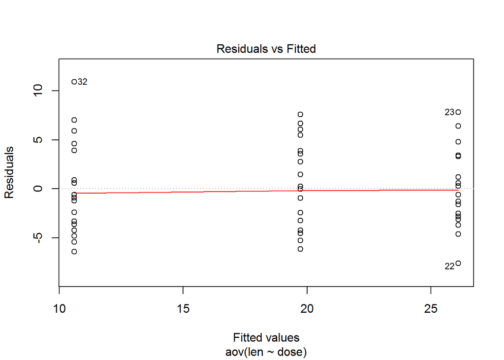

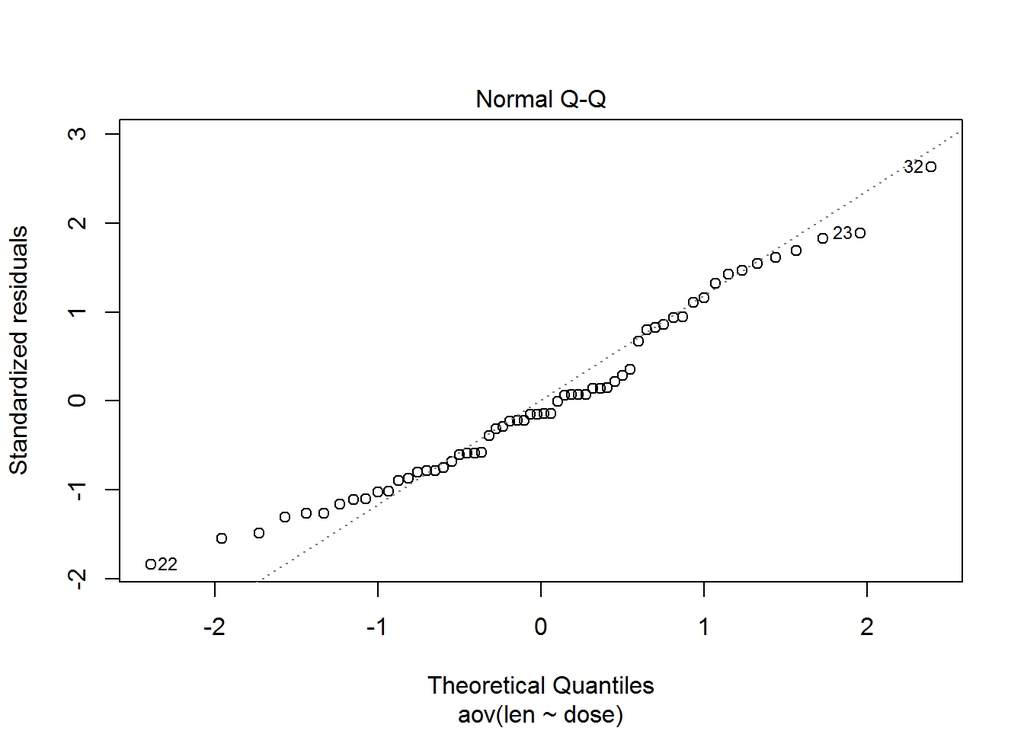

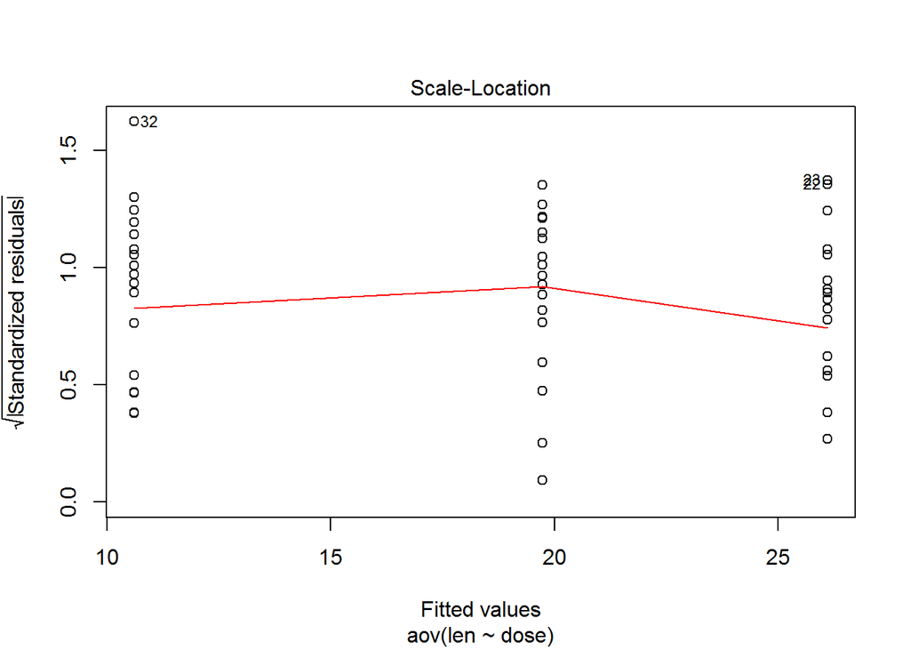

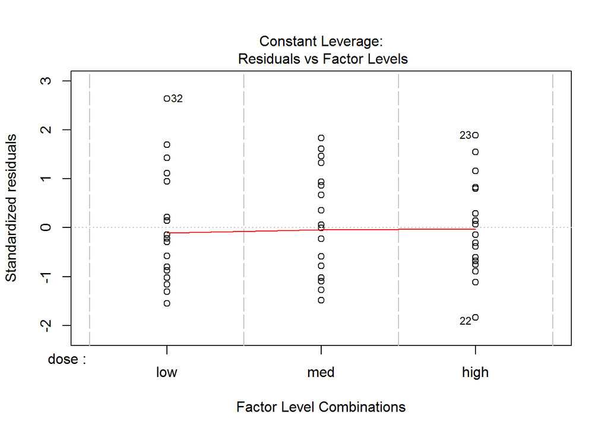

```r
plot(output)
```

### Post Hoc Tests

#### Pairwise T Test

The function pairwise.t.test computes the pair-wise comparisons between group means with corrections for multiple testing. The general form is pairwise.t.test(response, factor, p.adjust = method, alternative = c(“two.sided”,“less”, “greater”))

```r
pairwise.t.test(ToothGrowth$len, ToothGrowth$dose,  p.adjust="bonferroni")
```

```
##
##  Pairwise comparisons using t tests with pooled SD
##
## data:  ToothGrowth$len and ToothGrowth$dose
##
##      low                 med
## med  0.00000002009175020 -
## high 0.00000000000000044 0.00004327810462139
##
## P value adjustment method: bonferroni
```

### Anova by Supplement & Dose

#### ANOVA

```r
output <- aov(len ~ supp + dose, data=ToothGrowth)
model.tables(output,"means",se=T)
```

```
## Tables of means
## Grand mean
##
## 18.81333
##
##  supp
## supp
##     OJ     VC
## 20.663 16.963
##
##  dose
## dose
##    low    med   high
## 10.605 19.735 26.100
##
## Standard errors for differences of means
##           supp   dose
##         0.9883 1.2104
## replic.     30     20
```

```r
summary(output)
```

```
##             Df Sum Sq Mean Sq F value               Pr(>F)
## supp         1  205.4   205.4   14.02             0.000429 ***
## dose         2 2426.4  1213.2   82.81 < 0.0000000000000002 ***
## Residuals   56  820.4    14.7
## ---
## Signif. codes:  0 '***' 0.001 '**' 0.01 '*' 0.05 '.' 0.1 ' ' 1
```

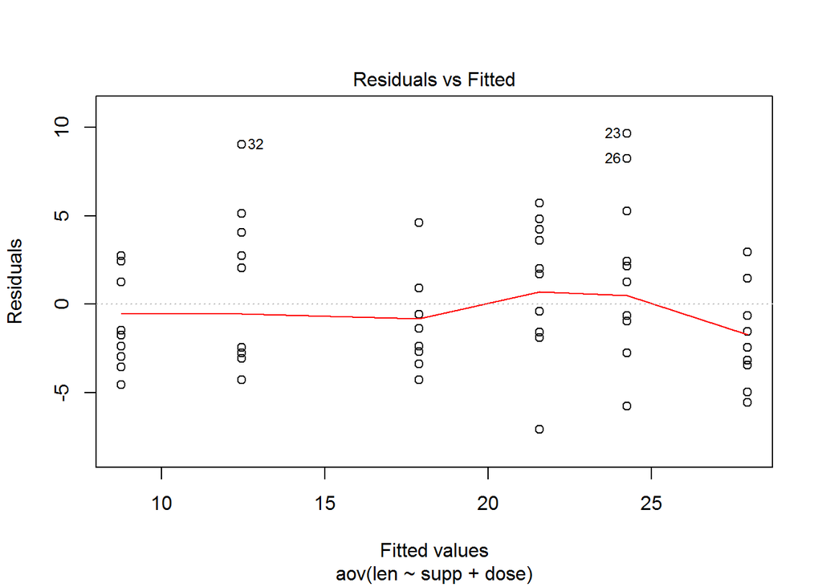

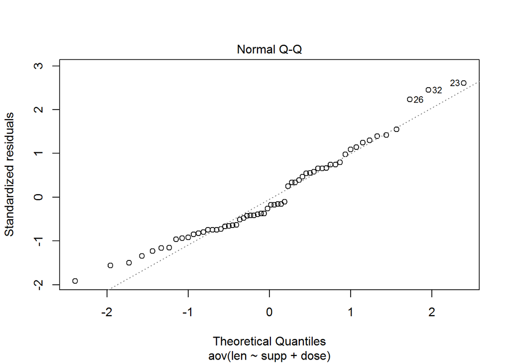

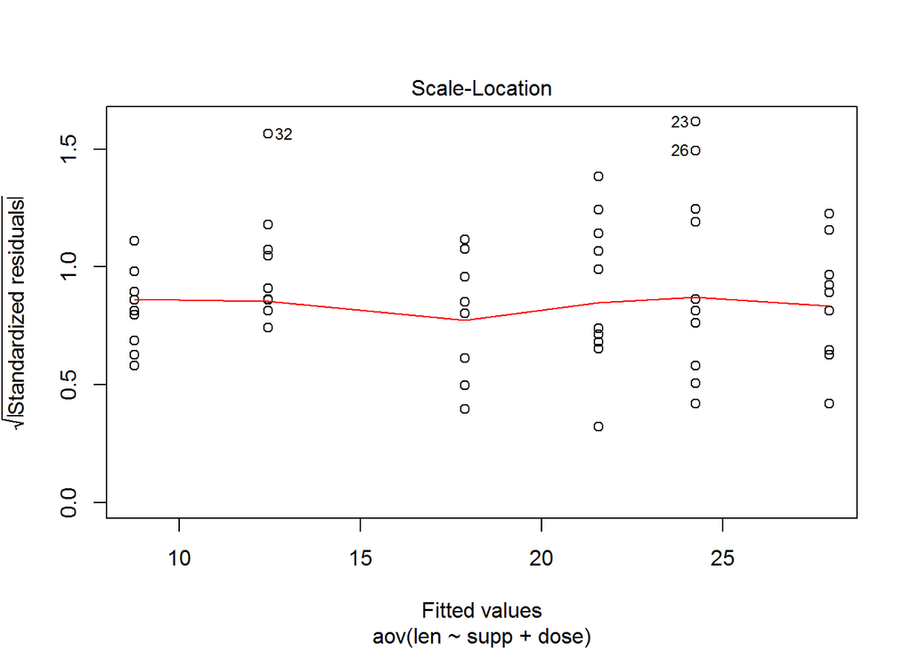

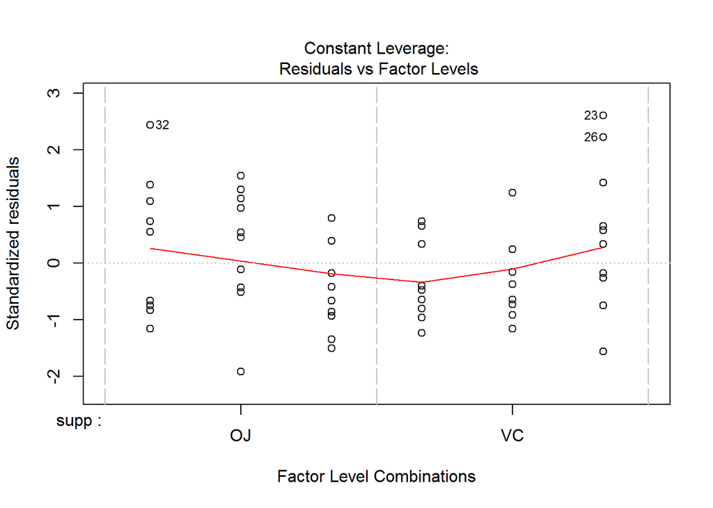

```r
plot(output)
```

```r
TukeyHSD(output)
```

```
##   Tukey multiple comparisons of means
##     95% family-wise confidence level
##
## Fit: aov(formula = len ~ supp + dose, data = ToothGrowth)
##
## $supp
##       diff       lwr       upr     p adj
## VC-OJ -3.7 -5.679762 -1.720238 0.0004293
##
## $dose
##            diff       lwr       upr    p adj
## med-low   9.130  6.215909 12.044091 0.000000
## high-low 15.495 12.580909 18.409091 0.000000
## high-med  6.365  3.450909  9.279091 0.000007
```

#### ANOVA with Interaction

```r
output <- aov(len ~ supp*dose,data=ToothGrowth )
model.tables(output,"means", se=T)
```

```
## Tables of means
## Grand mean
##
## 18.81333
##
##  supp
## supp
##     OJ     VC
## 20.663 16.963
##
##  dose
## dose
##    low    med   high
## 10.605 19.735 26.100
##
##  supp:dose
##     dose
## supp low   med   high
##   OJ 13.23 22.70 26.06
##   VC  7.98 16.77 26.14
##
## Standard errors for differences of means
##           supp   dose supp:dose
##         0.9376 1.1484    1.6240
## replic.     30     20        10
```

```r
summary(output)
```

```
##             Df Sum Sq Mean Sq F value               Pr(>F)
## supp         1  205.4   205.4  15.572             0.000231 ***
## dose         2 2426.4  1213.2  92.000 < 0.0000000000000002 ***
## supp:dose    2  108.3    54.2   4.107             0.021860 *
## Residuals   54  712.1    13.2
## ---
## Signif. codes:  0 '***' 0.001 '**' 0.01 '*' 0.05 '.' 0.1 ' ' 1
```

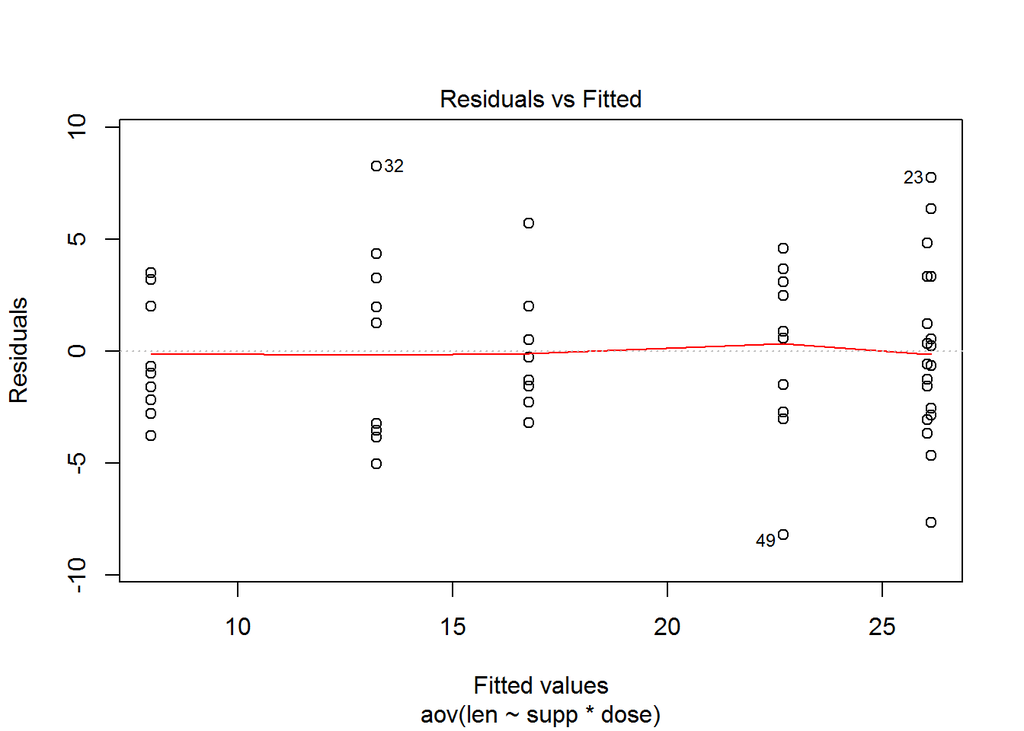

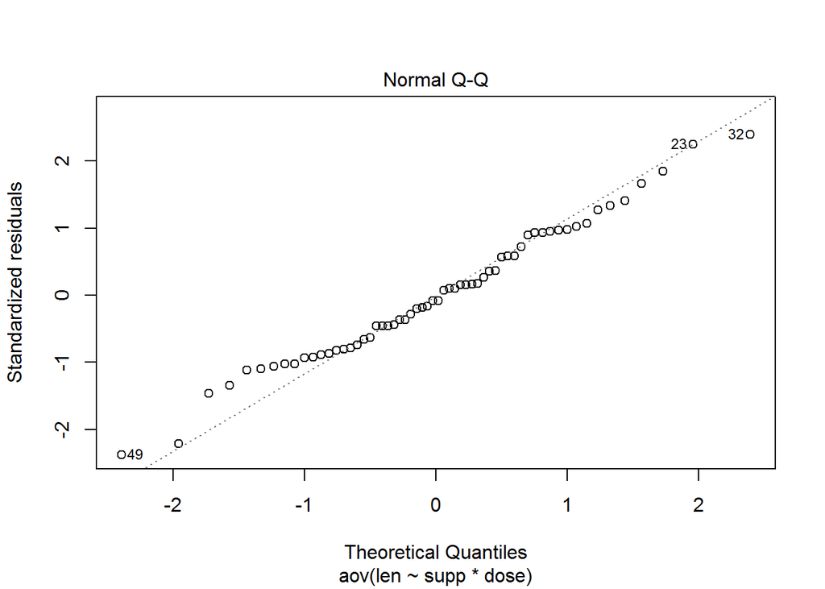

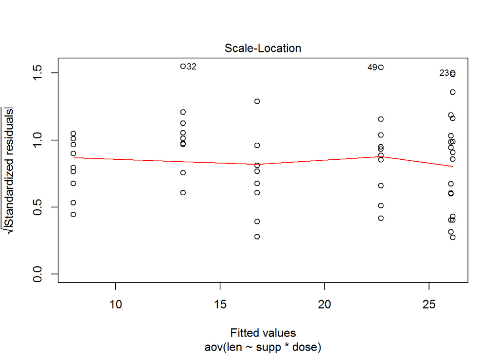

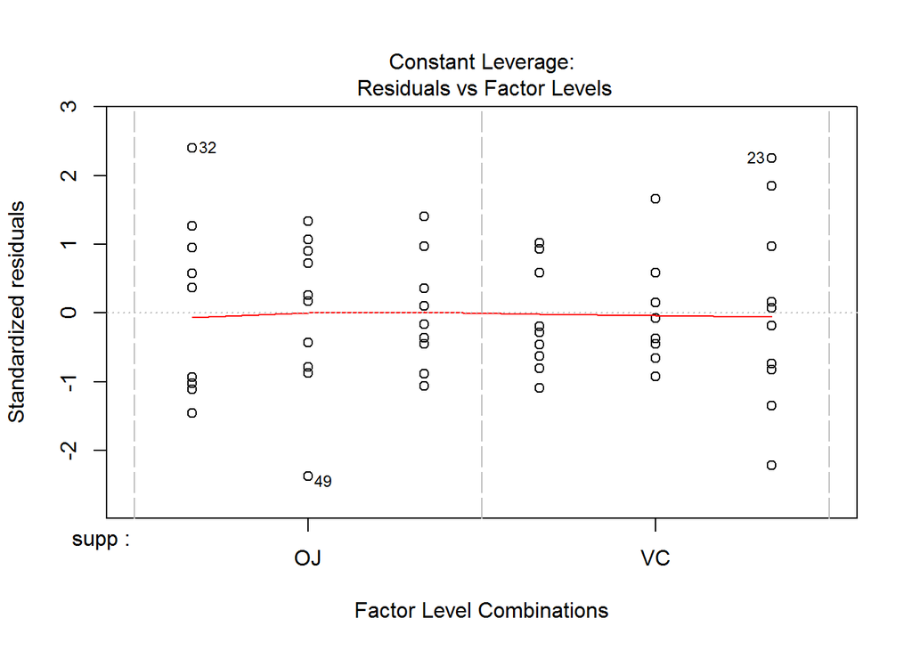

```r
plot(output)
```

```r
TukeyHSD(output)
```

```
##   Tukey multiple comparisons of means
##     95% family-wise confidence level
##
## Fit: aov(formula = len ~ supp * dose, data = ToothGrowth)
##
## $supp
##       diff       lwr       upr     p adj
## VC-OJ -3.7 -5.579828 -1.820172 0.0002312
##
## $dose
##            diff       lwr       upr     p adj
## med-low   9.130  6.362488 11.897512 0.0000000
## high-low 15.495 12.727488 18.262512 0.0000000
## high-med  6.365  3.597488  9.132512 0.0000027
##
## $`supp:dose`
##                  diff        lwr        upr     p adj
## VC:low-OJ:low   -5.25 -10.048124 -0.4518762 0.0242521
## OJ:med-OJ:low    9.47   4.671876 14.2681238 0.0000046
## VC:med-OJ:low    3.54  -1.258124  8.3381238 0.2640208
## OJ:high-OJ:low  12.83   8.031876 17.6281238 0.0000000
## VC:high-OJ:low  12.91   8.111876 17.7081238 0.0000000
## OJ:med-VC:low   14.72   9.921876 19.5181238 0.0000000
## VC:med-VC:low    8.79   3.991876 13.5881238 0.0000210
## OJ:high-VC:low  18.08  13.281876 22.8781238 0.0000000
## VC:high-VC:low  18.16  13.361876 22.9581238 0.0000000
## VC:med-OJ:med   -5.93 -10.728124 -1.1318762 0.0073930
## OJ:high-OJ:med   3.36  -1.438124  8.1581238 0.3187361
## VC:high-OJ:med   3.44  -1.358124  8.2381238 0.2936430
## OJ:high-VC:med   9.29   4.491876 14.0881238 0.0000069
## VC:high-VC:med   9.37   4.571876 14.1681238 0.0000058
## VC:high-OJ:high  0.08  -4.718124  4.8781238 1.0000000
```

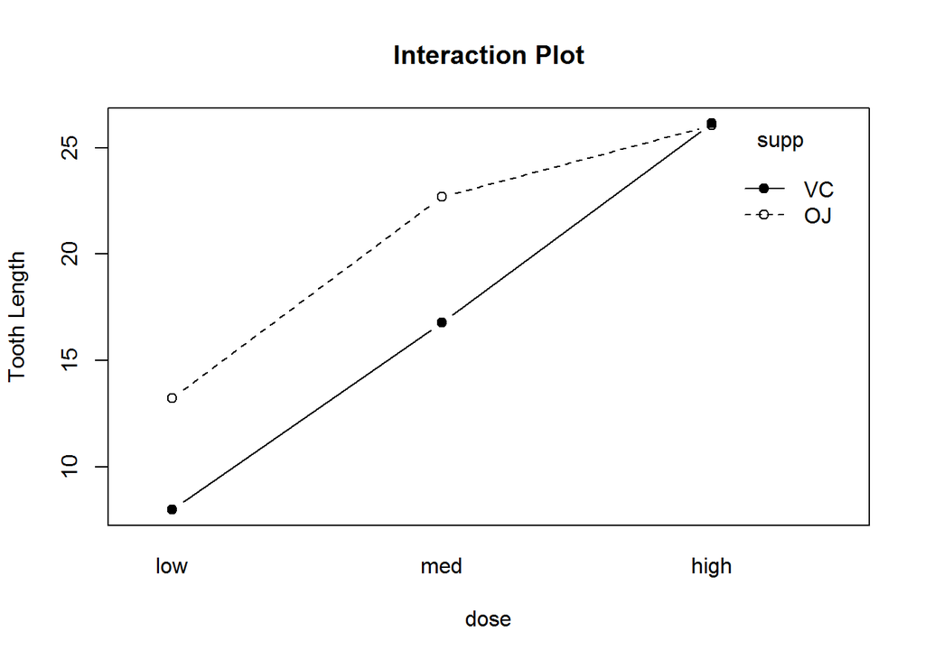

```r
##Interaction Plt
with(ToothGrowth, interaction.plot(x.factor=dose, trace.factor=supp,response=len, fun=mean, type="b", legend=T, ylab="Tooth Length", main="Interaction Plot", pch=c(1,19)))
```

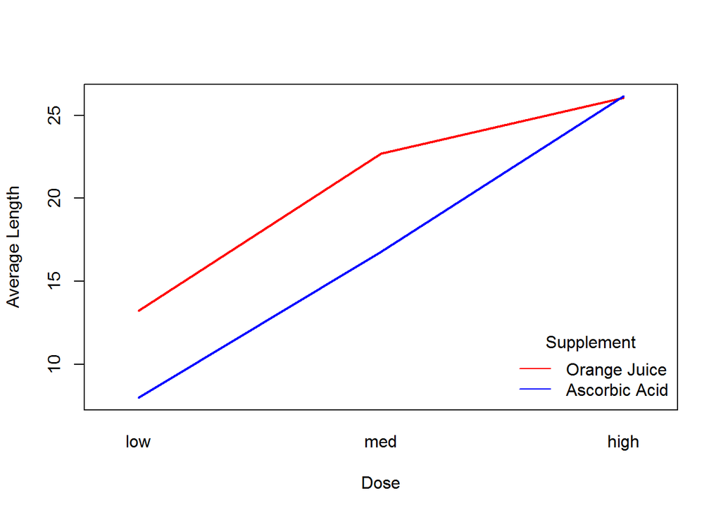

```r
##Interaction Plot and
with(ToothGrowth,
interaction.plot(dose, supp, len, fun=mean,
xlab="Dose", ylab="Average Length",
lty=1, lwd=2, col=c("red", "blue"), legend=FALSE))
legend("bottomright", c("Orange Juice", "Ascorbic Acid"),
col=c("red", "blue"), lty=1, bty="n", title="Supplement")
```

## Linear Model

```r
fit <- aov(len~dose+supp, data=ToothGrowth)
summary(fit)
```

```
##             Df Sum Sq Mean Sq F value               Pr(>F)
## dose         2 2426.4  1213.2   82.81 < 0.0000000000000002 ***
## supp         1  205.4   205.4   14.02             0.000429 ***
## Residuals   56  820.4    14.7
## ---
## Signif. codes:  0 '***' 0.001 '**' 0.01 '*' 0.05 '.' 0.1 ' ' 1
```

```r
##Make a
x <- ToothGrowth$len[ToothGrowth$dose=="high"]-ToothGrowth$len[ToothGrowth$dose=="med"]
summary(x)
```

```
##    Min. 1st Qu.  Median    Mean 3rd Qu.    Max.
##  -4.300   2.825   5.750   6.365   9.425  18.700
```

```r
results <-t.test(x,  alternative = "greater")
results
```

```
##
##  One Sample t-test
##
## data:  x
## t = 4.6046, df = 19, p-value = 0.00009671
## alternative hypothesis: true mean is greater than 0
## 95 percent confidence interval:
##  3.974821      Inf
## sample estimates:
## mean of x
##     6.365
```

```r
x <- ToothGrowth$len[ToothGrowth$dose=="med"]-ToothGrowth$len[ToothGrowth$dose=="low"]
summary(x)
```

```
##    Min. 1st Qu.  Median    Mean 3rd Qu.    Max.
##  -2.000   4.875   8.200   9.130  14.000  17.600
```

```r
results <-t.test(x,  alternative = "greater")
results
```

```
##
##  One Sample t-test
##
## data:  x
## t = 6.9669, df = 19, p-value = 0.0000006127
## alternative hypothesis: true mean is greater than 0
## 95 percent confidence interval:
##  6.863996      Inf
## sample estimates:
## mean of x
##      9.13
```

```r
x <- ToothGrowth$len[ToothGrowth$dose=="high"]-ToothGrowth$len[ToothGrowth$dose=="low"]
summary(x)
```

```
##    Min. 1st Qu.  Median    Mean 3rd Qu.    Max.
##    4.80   10.30   16.70   15.50   19.77   26.60
```

```r
results <-t.test(x,  alternative = "greater")
results
```

```
##
##  One Sample t-test
##
## data:  x
## t = 11.2915, df = 19, p-value = 0.0000000003595
## alternative hypothesis: true mean is greater than 0
## 95 percent confidence interval:
##  13.12216      Inf
## sample estimates:
## mean of x
##    15.495
```

```r
x <- ToothGrowth$len[ToothGrowth$supp=="OJ"]-ToothGrowth$len[ToothGrowth$supp=="VC"]
summary(x)
```

```
##    Min. 1st Qu.  Median    Mean 3rd Qu.    Max.
## -11.500  -1.450   4.850   3.700   8.325  12.200
```

```r
results <-t.test(x,  alternative = "greater")
results
```

```
##
##  One Sample t-test
##
## data:  x
## t = 3.3026, df = 29, p-value = 0.001275
## alternative hypothesis: true mean is greater than 0
## 95 percent confidence interval:
##  1.796409      Inf
## sample estimates:
## mean of x
##       3.7
```

### One-Sample T-Tests

```r
# Add the ID column to the data frame
dataIDAdded <- data.frame(ToothGrowth,PigID=rep(c(1:10),6))
tgdata <- dcast(dataIDAdded,dose+PigID~supp,value.var="len")

# Adjust the column names of the data frame
names(tgdata)[-(1: 2)] <- paste("supp_", names(tgdata)[-(1: 2)], sep = "")

# Add a difference value column to the data frame
tgdata <- mutate(tgdata,diffval=supp_OJ-supp_VC)

##
tgdata05 <- subset(tgdata,dose=="low")
t.test(tgdata05$diffval)
```

```
##
##  One Sample t-test
##
## data:  tgdata05$diffval
## t = 2.9791, df = 9, p-value = 0.01547
## alternative hypothesis: true mean is not equal to 0
## 95 percent confidence interval:
##  1.263458 9.236542
## sample estimates:
## mean of x
##      5.25
```

```r
tgdata10 <- subset(tgdata,dose=="med")
t.test(tgdata10$diffval)
```

```
##
##  One Sample t-test
##
## data:  tgdata10$diffval
## t = 3.3721, df = 9, p-value = 0.008229
## alternative hypothesis: true mean is not equal to 0
## 95 percent confidence interval:
##  1.951911 9.908089
## sample estimates:
## mean of x
##      5.93
```

```r
tgdata20 <- subset(tgdata,dose=="high")
t.test(tgdata20$diffval)
```

```
##
##  One Sample t-test
##
## data:  tgdata20$diffval
## t = -0.0426, df = 9, p-value = 0.967
## alternative hypothesis: true mean is not equal to 0
## 95 percent confidence interval:
##  -4.328976  4.168976
## sample estimates:
## mean of x
##     -0.08
```